# Final Report

Mia Sumera

2025-12-10

# Introduction

The objective of this report is to explore factors linked to dropout and academic success through descriptive statistics and visualizations. I will investigate demographic patterns, academic performance trends, and socio-economic influence on outcomes. Additionally, I will examine the distribution of students who dropped out, remained enrolled, or graduated.

# Table 1

Table 1. Student Characteristics by Academic Outcome

|  | Dropout | Enrolled | Graduate |
| --- | --- | --- | --- |
| N | 1421.0 | 794.0 | 2209.0 |
| Age (mean) | 26.1 | 22.4 | 21.8 |
| Male (%) | 49.3 | 38.7 | 24.8 |
| International (%) | 2.3 | 3.0 | 2.4 |
| Scholarship (%) | 9.4 | 16.4 | 37.8 |
| Educational Special Needs (%) | 1.2 | 1.4 | 1.0 |
| Admission Grade (mean) | 62.5 | 62.8 | 64.4 |
| First Semester Grade (mean) | 36.3 | 55.6 | 63.2 |
| Second Semester Grade (mean) | 29.5 | 55.6 | 63.5 |

Scholarship recipients were more common among graduates (37.8%) than enrolled (16.4%) and students who dropped out (9.4%). Dropout students had the lowest mean admission grades (62.5) and showed weaker performance in the first (36.3) and second semester (29.5) when compared to enrolled students (55.6, 55.6) and graduated students (63.2, 63.5). Students who graduated had the highest admission and semester grades.

# Figure 1

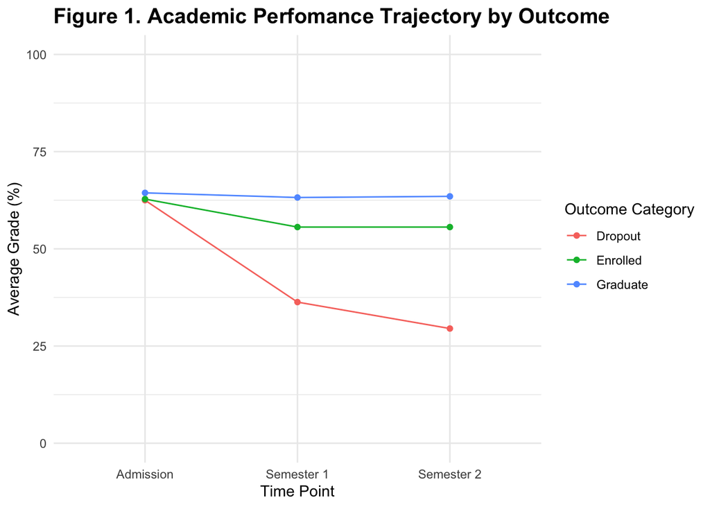

Figure 1 is a line chart showing the academic performance trajectory from admission to second semester. This shows that although students enter their programs with similar grade averages at admission, their performance differs, with those who dropped out having the sharpest decline from admission to the second semester.